# Auswertung v1.1

05 Oktober 2015

# 1 Datensätze

```
## 'data.frame':    525 obs. of  22 variables:
##  $ x.schlag: Factor w/ 15 levels "bb","bk","e",..: 3 3 3 3 3 3 4 4 4 4 ...
##  $ x.ktyp  : Factor w/ 9 levels "bgk","bk","dk",..: NA 7 NA 7 1 6 4 4 1 1 ...
##  $ x.koa   : int  13 14 14 14 14 14 10 13 10 13 ...
##  $ x.kod   : int  NA 2 2 2 2 2 5 NA 5 NA ...
##  $ x.wt    : int  NA 26 26 26 26 26 23 NA 23 NA ...
##  $ x.wb    : Factor w/ 4 levels "r","w","b","s": NA 4 4 4 4 4 2 NA 2 NA ...
##  $ x.kz    : Factor w/ 4 levels "d","sb","lb",..: 4 4 4 4 4 2 4 4 4 2 ...
##  $ x.vn    : Factor w/ 7 levels "0","1","2","3",..: 2 1 2 2 2 2 1 2 1 4 ...
##  $ x.aves  : Factor w/ 13 levels "0","1","2","3",..: 4 1 1 1 5 3 1 3 2 3 ...
##  $ x.mamm  : Factor w/ 3 levels "0","1","2": 1 1 1 1 1 1 1 1 1 1 ...
##  $ x.invert: Factor w/ 6 levels "0","1","2","3",..: 1 1 2 2 1 1 1 1 1 1 ...
##  $ x.flkot : Factor w/ 2 levels "0","1": 2 2 2 2 2 1 2 2 2 1 ...
##  $ x.qtyp  : Factor w/ 6 levels "0","1","2","3",..: 1 1 1 1 1 1 1 1 1 1 ...
##  $ x.flart : Factor w/ 10 levels "0","M.daubentonii",..: 1 1 1 1 1 1 1 1 1 1 ...
##  $ y.kz    : int  4 4 4 4 4 2 4 4 4 2 ...
##  $ y.vn    : int  1 0 1 1 1 1 0 1 0 3 ...
##  $ y.flkot : int  1 1 1 1 1 0 1 1 1 0 ...
##  $ y.flges : int  0 0 0 0 0 0 0 0 0 0 ...
##  $ y.flm   : int  0 0 0 0 0 0 0 0 0 0 ...
##  $ y.flw   : int  0 0 0 0 0 0 0 0 0 0 ...
##  $ y.flad  : int  0 0 0 0 0 0 0 0 0 0 ...
##  $ y.fljuv : int  0 0 0 0 0 0 0 0 0 0 ...
```

Einen Überblick über den Umfang der Kontrollen in den einzelnen Jahren geben die Kontrollierten Schläge.

```r
# Kontrollen ~ Jahr
tab.schlag <- with(df, table(x.schlag, x.koa))
m.schlag <- as.data.frame.matrix(tab.schlag)
m.schlag <- rbind(m.schlag, Summe=colSums(m.schlag))
m.schlag <- cbind(m.schlag, gesamt=rowSums(m.schlag))
```

```r
Table1 <- pander(
         m.schlag,
         caption="Datensätze pro Schlag",

         digits=0
         )
Table1
```

Datensätze pro Schlag

|  | 10 | 11 | 12 | 13 | 14 | 15 | gesamt |
| --- | --- | --- | --- | --- | --- | --- | --- |
| **bb** | 15 | 17 | 0 | 0 | 9 | 0 | 41 |
| **bk** | 1 | 4 | 0 | 0 | 19 | 0 | 24 |
| **e** | 0 | 0 | 0 | 1 | 5 | 0 | 6 |
| **g** | 8 | 0 | 0 | 6 | 0 | 4 | 18 |
| **hb** | 6 | 0 | 0 | 0 | 0 | 0 | 6 |
| **hk** | 21 | 0 | 0 | 16 | 0 | 27 | 64 |
| **ho** | 9 | 1 | 0 | 8 | 11 | 0 | 29 |
| **hz** | 14 | 3 | 18 | 0 | 2 | 29 | 66 |
| **ki** | 8 | 0 | 1 | 5 | 0 | 7 | 21 |
| **kle** | 4 | 3 | 0 | 0 | 7 | 0 | 14 |
| **klo** | 20 | 19 | 0 | 0 | 20 | 0 | 59 |
| **m** | 31 | 0 | 0 | 35 | 0 | 33 | 99 |
| **rk** | 24 | 0 | 0 | 21 | 0 | 0 | 45 |
| **sg** | 6 | 0 | 5 | 0 | 0 | 6 | 17 |
| **ss** | 2 | 0 | 0 | 13 | 0 | 0 | 15 |
| **Summe** | 169 | 47 | 24 | 105 | 73 | 106 | 524 |

# 2 Welche Arten haben ihre Sommerquartiere im Untersuchungsgebiet?

```r
levels(df$x.flart)
```

```
##  [1] "0"                     "M.daubentonii"
##  [3] "M.myotis"              "M.mystacinus/brandtii"
##  [5] "M.nattereri"           "Nyc.noctula"
##  [7] "Pip"                   "Pip.nathusii"
##  [9] "Pip.pygmaeus"          "Plec.auritus"
```

Von 2010 bis 2015 wurden acht Arten sowie nicht weiter bestimmte *Pipistrellus*-Arten gefunden:

- Wasserfledermaus (*Myotis daubentonii*)
- Großes Mausohr (*Myotis myotis*)
- Bartfledermäuse (*Myotis mystacinus* oder *Myotis brandtii*)
- Fransenfledermaus (*Myotis nattereri*)
- Großer Abernsegler (*Nyctalus noctula*)
- Rauhautfledermaus (*Pipistrellus nathusii*)
- Mückenfledermaus (*Pipistrellus pygmaeus*)
- Braunes Langohr (*Plecotus auritus*)

```r
# Quartiere pro Art
tab.art <- with(df, table(x.flart, x.koa))
m.art <- as.data.frame.matrix(tab.art)
m.art <- m.art[-1,]
m.art <- rbind(m.art, Summe=colSums(m.art))
m.art <- cbind(m.art, gesamt=rowSums(m.art))
```

```r
Table2 <- pander(
         m.art,
         caption="Quartiere pro Art",
         digits=0,
         split.table=Inf
         )
Table2
```

Quartiere pro Art

|  | 10 | 11 | 12 | 13 | 14 | 15 | gesamt |
| --- | --- | --- | --- | --- | --- | --- | --- |
| **M.daubentonii** | 1 | 6 | 0 | 2 | 1 | 6 | 16 |
| **M.myotis** | 2 | 0 | 0 | 2 | 1 | 0 | 5 |
| **M.mystacinus/brandtii** | 1 | 0 | 0 | 0 | 0 | 0 | 1 |
| **M.nattereri** | 15 | 10 | 2 | 10 | 21 | 16 | 74 |
| **Nyc.noctula** | 1 | 0 | 0 | 0 | 0 | 0 | 1 |
| **Pip** | 0 | 0 | 0 | 1 | 0 | 0 | 1 |
| **Pip.nathusii** | 2 | 0 | 0 | 0 | 0 | 0 | 2 |
| **Pip.pygmaeus** | 0 | 1 | 0 | 1 | 0 | 0 | 2 |
| **Plec.auritus** | 8 | 0 | 0 | 4 | 0 | 1 | 13 |
| **Summe** | 30 | 17 | 2 | 20 | 23 | 23 | 115 |

```r
# Individuen pro Art
df.ind.art <- ddply(
            df,
            .(x.koa, x.flart),
            summarise, Individuen = sum(y.flges)
            )
df.ind.art <- subset(df.ind.art, x.flart != 0)
```

```r
Table3 <- pander(
         df.ind.art,
         caption="Summe der Individuen pro Art",
         digits=0
         )
Table3
```

Summe der Individuen pro Art

|  | x.koa | x.flart | Individuen |
| --- | --- | --- | --- |
| **2** | 10 | M.daubentonii | 1 |
| **3** | 10 | M.myotis | 2 |
| **4** | 10 | M.mystacinus/brandtii | 4 |
| **5** | 10 | M.nattereri | 118 |
| **6** | 10 | Nyc.noctula | 3 |
| **7** | 10 | Pip.nathusii | 2 |
| **8** | 10 | Plec.auritus | 76 |
| **10** | 11 | M.daubentonii | 50 |
| **11** | 11 | M.nattereri | 61 |
| **12** | 11 | Pip.pygmaeus | 1 |
| **14** | 12 | M.nattereri | 13 |
| **16** | 13 | M.daubentonii | 23 |
| **17** | 13 | M.myotis | 2 |
| **18** | 13 | M.nattereri | 47 |
| **19** | 13 | Pip | 1 |
| **20** | 13 | Pip.pygmaeus | 1 |
| **21** | 13 | Plec.auritus | 20 |
| **23** | 14 | M.daubentonii | 4 |
| **24** | 14 | M.myotis | 2 |
| **25** | 14 | M.nattereri | 136 |
| **28** | 15 | M.daubentonii | 29 |
| **29** | 15 | M.nattereri | 95 |
| **30** | 15 | Plec.auritus | 6 |

```r
# kontrollierte Schläge pro Jahr

v.schlag <- rep(0, length(levels(df$x.koa))) # leerer Vektor der Länge der Kontrollen
f.temp <- function(x){
    temp <- subset(df, x.koa == x, select="x.schlag")
    temp <- as.numeric(table(temp))
    temp <- subset(temp, temp != 0)
    temp <- length(temp)
    temp
} # ermittelt die Anzahl der kontrollierten Schläge (Level != 0)
for(i in 1:6){
    x <- c(10:15)[i]
    v.schlag[i] <- f.temp(x)
} # schreibt die Werte in den Vektor

# Summe der Individuen pro Jahr
df.ind.koa <- ddply(df, .(x.koa), summarise, ArtSumme = sum(y.flges))
df.ind.koa$counts.schlag <- v.schlag
df.ind.koa$ArtSummeProSchlag <- df.ind.koa$ArtSumme / v.schlag
```

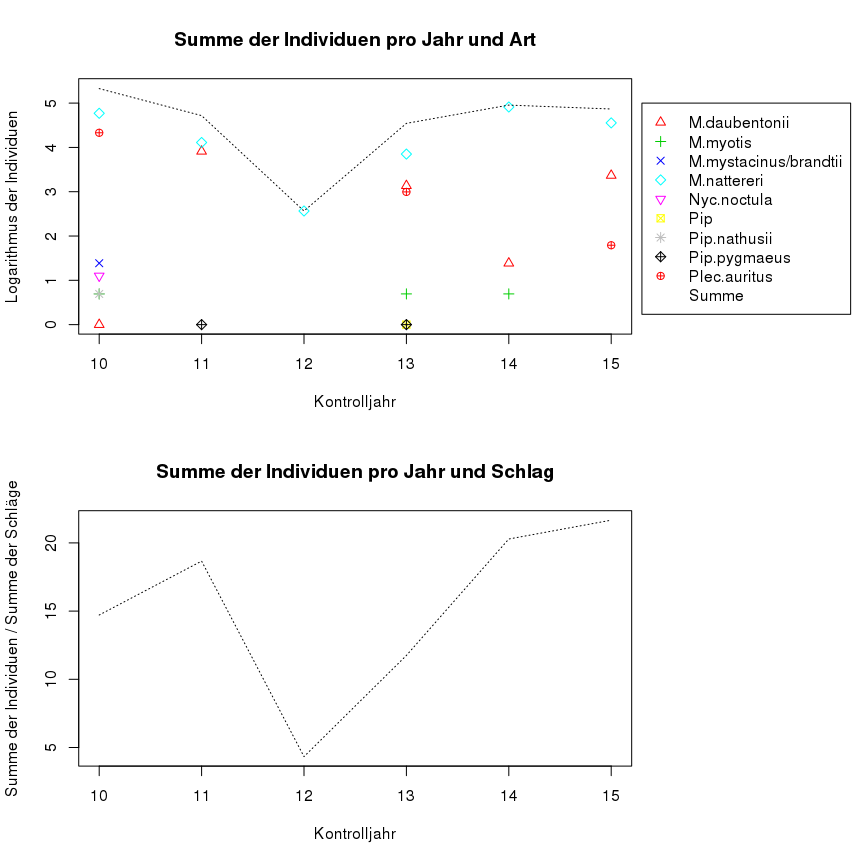

**oben:** Zählergebnisse der Arten im Vergleich im logarithmischen Maßstab **unten:** Gesamtzählergebnisse korrigiert um die Anzahl der kontrollierten Schläge

```r
.parsave <- par(no.readonly=T)
par(xpd=T,
    mar=.parsave$mar + c(0,0,0,10),
    mfrow=c(2,1)
    )

plot(
     log(Individuen) ~ x.koa,
     data = df.ind.art,
     ylim = c(0, log(max(df.ind.koa$ArtSumme) + 2)),
     type = "n",
     main = "Summe der Individuen pro Jahr und Art",
     xlab = "Kontrolljahr",
     ylab = "Logarithmus der Individuen"
     )

# Punkte für die Arten
for(i in seq_along(levels(df.ind.art$x.flart))) {
    points(
           log(Individuen) ~ x.koa,
           data = subset(
                 df.ind.art,
                 x.flart == levels(df.ind.art$x.flart)[i]
                 ),
           col = i,
           pch = i
           )
}

lines(log(ArtSumme) ~ x.koa, data=df.ind.koa, lty=3)

legend(
       15.3, 5,
       c(levels(df.ind.art$x.flart)[-1], "Summe"),
       col=c(seq_along(levels(df.ind.art$x.flart)[-1]) + 1, NA), # die Null braucht keiner
       pch=c(seq_along(levels(df.ind.art$x.flart)[-1]) + 1, NA), # die Null braucht keiner
       lty=c(rep(0, length(levels(df.ind.art$x.flart)[-1])), 3)
       )

plot(
     ArtSummeProSchlag ~ x.koa,
     data = df.ind.koa,
     type = "l",
     lty = 3,
     main = "Summe der Individuen pro Jahr und Schlag",
     xlab = "Kontrolljahr",
     ylab = "Summe der Individuen / Summe der Schläge"
     )
```

```r
par(.parsave)
```

Die Wasserfledermaus (**Myotis daubentonii**), die 2010 nur mit einem Individuum beobachtet wurde (s. Tabelle 3), scheint weitaus häufiger zu sein. Da die Schwankungen in den Zählergebnissen nicht mit denen in den Gebieten Rotes Kreuz / Mitterbachl, die offenes Wasser bieten, übereinstimmen (s. Tabelle 1), ist von einer methodischen Zählungenauigkeit auszugehen. Die Fransenfledermaus (**Myotis nattereri**) ist nach wie vor die dominierende Art im Feilenforst. Leider lässt sich beim Braunen Langohr (**Plecotus auritus**) ein deutlicher Rückgang in der Quartierzahl verzeichnen. Es kann sein, dass 2010 ein Ausreißer nach oben war, es kann immer noch Zählungenauigkeit sein, aber es ist ein deutlicher Rückgang zu befürchten.

Insgesamt schwanken die Zählergebnisse deutlich. Verantwortlich dafür dürfte das Verhalten der Waldfledermäuse sein, regelmäßig ihre Quartiere zu wechseln. Um konstantere Zahlen zu bekommen, und eine Aussage über die Entwicklung treffen zu können, müsste das gesamte Untersuchungsgebiet an einem Tag kontrolliert werden, wozu es ungefähr fünf Trupps à zwei bis drei Kontrolleuren, von denen mindestens einer Artkenntnis hat, bräuchte.

# 3 Wo sind die Verbreitungsschwerpunkte?

Als geographische Anhaltspunkte dienen uns hier die von oben bereits bekannten Forst-Schläge.

```r
# Quartiere pro Schlag
tab.q.schlag <- with(
           subset(
              df,
              x.qtyp != 0
              ),
           table(x.schlag, x.koa))
m.q.schlag <- as.data.frame.matrix(tab.q.schlag)
m.q.schlag <- rbind(m.q.schlag, Summe=colSums(m.q.schlag))
m.q.schlag <- cbind(m.q.schlag, gesamt=rowSums(m.q.schlag))
```

```r
Table4 <- pander(
         m.q.schlag,
         caption="Quartiere pro Schlag",
         digits=0
         )
Table4
```

Quartiere pro Schlag

|  | 10 | 11 | 12 | 13 | 14 | 15 | gesamt |
| --- | --- | --- | --- | --- | --- | --- | --- |
| **bb** | 2 | 6 | 0 | 0 | 3 | 0 | 11 |
| **bk** | 0 | 1 | 0 | 0 | 8 | 0 | 9 |
| **e** | 0 | 0 | 0 | 0 | 0 | 0 | 0 |
| **g** | 1 | 0 | 0 | 1 | 0 | 1 | 3 |
| **hb** | 2 | 0 | 0 | 0 | 0 | 0 | 2 |
| **hk** | 2 | 0 | 0 | 3 | 0 | 4 | 9 |
| **ho** | 1 | 1 | 0 | 0 | 7 | 0 | 9 |
| **hz** | 1 | 1 | 1 | 0 | 1 | 6 | 10 |
| **ki** | 3 | 0 | 0 | 1 | 0 | 2 | 6 |
| **kle** | 0 | 1 | 0 | 0 | 3 | 0 | 4 |
| **klo** | 4 | 7 | 0 | 0 | 1 | 0 | 12 |
| **m** | 3 | 0 | 0 | 8 | 0 | 11 | 22 |
| **rk** | 7 | 0 | 0 | 7 | 0 | 0 | 14 |
| **sg** | 2 | 0 | 1 | 0 | 0 | 0 | 3 |
| **ss** | 0 | 0 | 0 | 0 | 0 | 0 | 0 |
| **Summe** | 28 | 17 | 2 | 20 | 23 | 24 | 114 |

```r
df.art.schlag <- ddply(df, .(x.koa, x.schlag), summarise, Individuen = sum(y.flges))
```

```r
# Kästen pro Schlag
v.kasten.schlag <- rep(0, length(df.art.schlag$Individuen))
for(
    i in seq_along(v.kasten.schlag)
    ){
    v.kasten.schlag[i] <- m.schlag[
                       paste0(df.art.schlag$x.schlag[i]),
                       paste0(df.art.schlag$x.koa[i])
                       ]
}
df.kasten.art.schlag <- df.art.schlag
df.kasten.art.schlag$Kastenzahl <- v.kasten.schlag
df.kasten.art.schlag$IndProKasten <- with(df.kasten.art.schlag,
                      Individuen / Kastenzahl
                      )
```

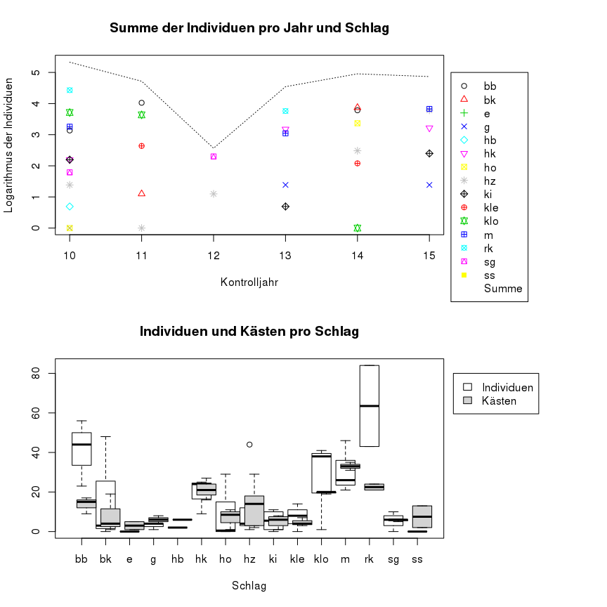

Individuen und Kästen pro Schlag

```r
par(xpd=T,
    mar=.parsave$mar + c(0,0,0,10),
    mfrow=c(2,1)
    )

plot(
     log(Individuen) ~ x.koa,
     data = df.art.schlag,
     ylim = c(0, log(max(df.ind.koa$ArtSumme) + 2)),
     type = "n",
     main = "Summe der Individuen pro Jahr und Schlag",
     xlab = "Kontrolljahr",
     ylab = "Logarithmus der Individuen"
     )

# Punkte für die Schläge
for(i in seq_along(levels(df.art.schlag$x.schlag))) {
    points(
           log(Individuen) ~ x.koa,
           data = subset(
                 df.art.schlag,
                 x.schlag == levels(df.art.schlag$x.schlag)[i]
                 ),
           col = i,
           pch = i
           )
}

lines(log(ArtSumme) ~ x.koa, data=df.ind.koa, lty=3)

legend(
       15.3, 5,
       c(levels(df.art.schlag$x.schlag), "Summe"),
       col=c(seq_along(levels(df.art.schlag$x.schlag)), NA),
       pch=c(seq_along(levels(df.art.schlag$x.schlag)), NA),
       lty=c(rep(0, length(levels(df.art.schlag$x.schlag))), 3)
       )

plot(
     Individuen ~ x.schlag,
     data=df.kasten.art.schlag,
     at=seq_along(levels(df.kasten.art.schlag$x.schlag)) - 0.2,
     col="white",
     main="Individuen und Kästen pro Schlag",
     xlab="Schlag",
     ylab=""
     )

plot(
     Kastenzahl ~ x.schlag,
     data=df.kasten.art.schlag,
     axes=0,
     xlab=NULL,
     ylab=NULL,
     col="lightgray",
     add=T
     )

legend(
       16.3, 80,
       c("Individuen", "Kästen"),
       c("white", "lightgray")
       )
```

```r
par(.parsave)
```

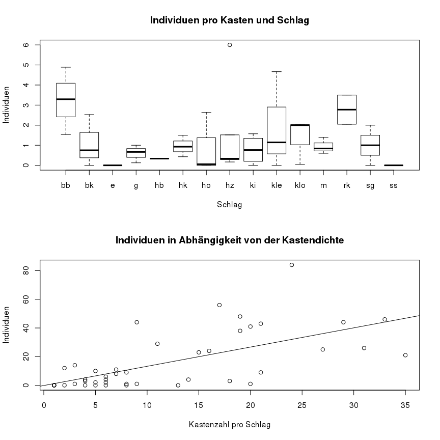

Korrellation Individuen- und Kastendichte

```r
par(mfrow=c(2,1))

plot(
     IndProKasten ~ x.schlag,
     data=df.kasten.art.schlag,
     main="Individuen pro Kasten und Schlag",
     xlab="Schlag",
     ylab="Individuen"
     )

plot(Individuen ~ Kastenzahl,
     data=df.kasten.art.schlag,
     main="Individuen in Abhängigkeit von der Kastendichte",
     xlab="Kastenzahl pro Schlag",
     ylab="Individuen"
     )
abline(lm(Individuen ~ Kastenzahl, data=df.kasten.art.schlag))
```

```r
par(.parsave)
```

Sowohl bei den Quartieren (Tabelle 4) als auch bei den Individuenzahlen zeigt sich eine Häufung in einer Reihe von Schlägen, die auf der Karte betrachtet weitgehend zusammenhängen. Bei näherer Betrachtung zeigt sich jedoch, dass dort auch die Kastendichte höher ist (Abb. 2). Die Abbildung 3 legt nahe, dass sowohl die Schläge an sich relevant sind, da sich die durchschnittliche Individuenzahl pro Kasten unterscheidet, als auch die Kastendichte.

```r
Model1 <- aov(Individuen ~ Kastenzahl + x.schlag, data=df.kasten.art.schlag)
```

```r
Table5 <- pander(
         Model1,
         caption="ANOVA: Individuen ~ Kastenzahl + Schlag"
         )
Table5
```

ANOVA: Individuen ~ Kastenzahl + Schlag

|  | Df | Sum Sq | Mean Sq | F value | Pr(>F) |
| --- | --- | --- | --- | --- | --- |
| **Kastenzahl** | 1 | 7038 | 7038 | 41.18 | 5.999e-07 |
| **x.schlag** | 14 | 5182 | 370.2 | 2.166 | 0.03976 |
| **Residuals** | 28 | 4785 | 170.9 | NA | NA |

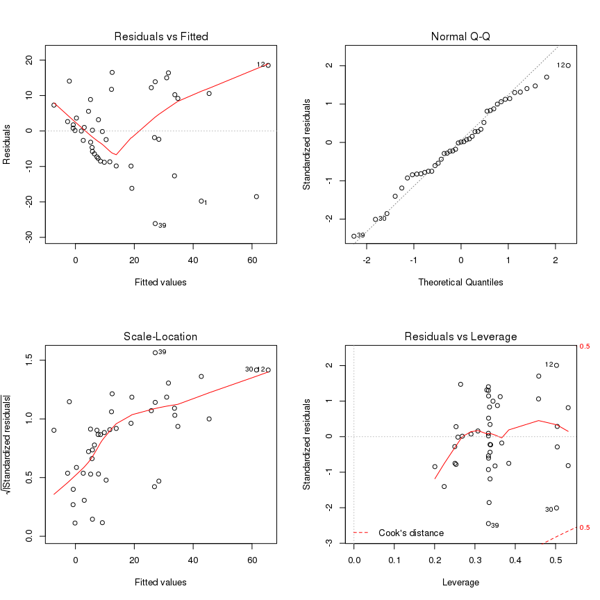

```r
par(mfrow=c(2,2))
plot(Model1)
```

Für den Bereich Rotes Kreuz / Mitterbachl dürften die Offenwasserflächen relevant sein, da diese ein gutes Nahrungsangebot generieren, für die Bereiche südlich der B300 dürfte die Nähe zu diesen relevant sein. Zudem bilden die bevorzugten Bereiche den Kern des Forstes mit seiner größten Ausdehnung.

# 4 Wie steht es um Quantität und Qualität der künstlichen Quartiere?

```r
# Kastenzahlen zu Levels von koa und kz zugeordnet
df.kz <- subset(df, select=c("x.koa", "x.kz"))
df.kz$freq <- rep(0, length(df.kz$x.koa)) # leerer Vektor der richtigen Länge

# ermittelt die Anzahl der kontrollierten Kästen für die Kombination aus koa und kz
f.temp <- function(i) {
    x <- df.kz$x.koa[i]
    y <- df.kz$x.kz[i]
    temp <- subset(df.kz, x.koa == x & x.kz == y)
    temp <- length(temp$freq)
    temp
}

# Schreibt die Werte in den Vektor
for(i in seq_along(df.kz$freq)) {
    df.kz$freq[i] <- f.temp(i)
}
```

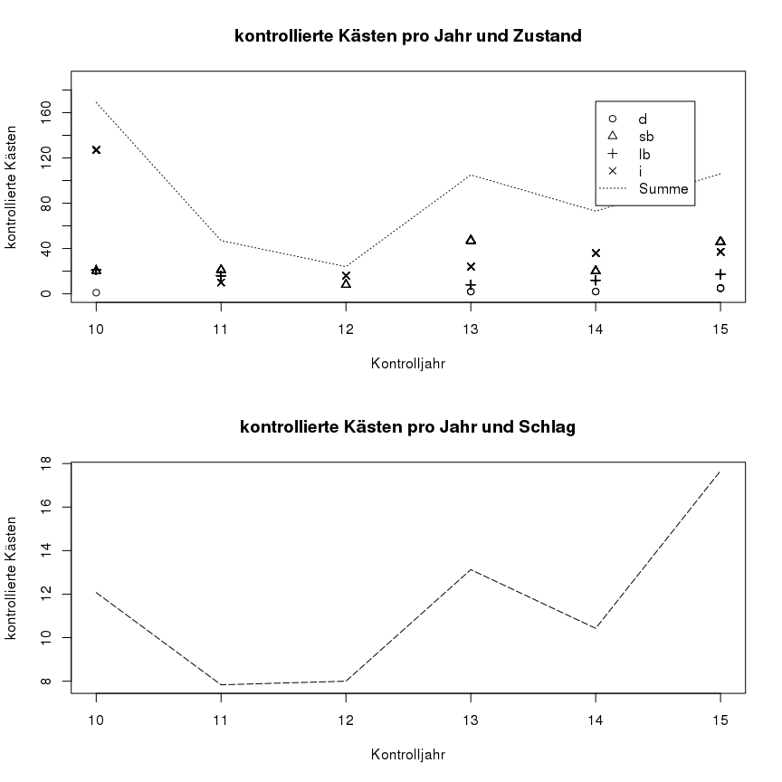

**oben:** Anzahl der kontrollierten Kästen in Summe und nach Kastenzustand **unten:** Summe der kontrollierten Kästen korrigiert durch die Anzahl der kontrollierten Schläge

```r
par(mfrow=c(2,1))

# leerer Plot
plot(
      freq ~ x.koa,
      data = df.kz,
      ylim = c(0, max(m.schlag[, -7]) + 20),
      type = "n",
      axes = 0,
      main = "kontrollierte Kästen pro Jahr und Zustand",
      xlab = "Kontrolljahr",
      ylab = "kontrollierte Kästen"
      )
axis(1)
axis(2, at=seq(0, max(m.schlag[, -7]) + 20, 20))
box()

# Punkte für die Kastenzustände
for(i in seq_along(levels(df.kz$x.kz))) {
    points(
         freq ~ x.koa,
         data = subset(
               df.kz,
               x.kz == levels(df.kz$x.kz)[i]
               ),
         pch = i
         )
}

# Summe der kontrollierten Kästen pro Jahr
lines(as.numeric(m.schlag["Summe",-7]) ~ as.numeric(10:15), lty=3)

legend(
       14, 170,
       c(levels(df.kz$x.kz), "Summe"),
       pch=c(1:4, NA),
       lty=c(rep(0,4),3)
       )

plot(
     as.numeric(m.schlag["Summe", -7]) / v.schlag ~ c(10:15),
     type="l",
     lty=5,
     main="kontrollierte Kästen pro Jahr und Schlag",
     xlab = "Kontrolljahr",
     ylab = "kontrollierte Kästen"
     )
```

Allerdings beinhaltet die obere Darstellung einen Fehler: Der Umfang der Kontrollen ist von Jahr zu Jahr unterschiedlich. Daher verwendet die untere Darstellung die Anzahl der kontrollierten Schläge als Maß für den Umfang der Kontrollen und korrigiert die die Summe um diesen Faktor.

Die korrigierte Kurve scheint nun also eine positive Entwicklung in der Kastenzahl darzustellen, was im folgenden zu Überprüfen gilt.

```r
# Werte von v.schlag in data frame mit den beiden freq's
df.kz.schlag <- data.frame(
               x.koa = df$x.koa,
               x.kz = df$x.kz,
               x.schlag = df$x.schlag,
               counts.kz = df.kz$freq,
               num.schlag = rep(0, length(df$x.koa))
               )
f.temp <- function(x) {
    temp <- c(10:15)
    x <- which(temp == x)
    v.schlag[x]
}
for(i in seq_along(df.kz.schlag$x.koa)) {
    x <- df.kz.schlag$x.koa[i]
    df.kz.schlag$num.schlag[i] <- f.temp(x)
}

# Anzahl der kontrollierten Schläge als Korrektur
# für die Anzahl der kontrollierten Kästen
df.kz.schlag$freq <- df.kz.schlag$counts.kz / df.kz.schlag$num.schlag


# ANOVA

Model2 <- lm(freq ~ x.koa, data=df.kz.schlag)
```

```r
summary(Model2)
```

```
##
## Call:
## lm(formula = freq ~ x.koa, data = df.kz.schlag)
##
## Residuals:
##    Min     1Q Median     3Q    Max
## -5.932 -2.613  0.587  3.068  3.473
##
## Coefficients:
##             Estimate Std. Error t value Pr(>|t|)
## (Intercept)  9.62318    0.81811  11.763  < 2e-16 ***
## x.koa       -0.36195    0.06542  -5.533 4.98e-08 ***
## ---
## Signif. codes:  0 '***' 0.001 '**' 0.01 '*' 0.05 '.' 0.1 ' ' 1
##
## Residual standard error: 2.933 on 523 degrees of freedom
## Multiple R-squared:  0.0553, Adjusted R-squared:  0.05349
## F-statistic: 30.61 on 1 and 523 DF,  p-value: 4.981e-08
```

```r
v.freq <- rep(0,6)

for(i in 10:15) {
    temp <- c(10:15)
    x <- which(temp == i)
    v.freq[x] <- with(
              subset(df.kz.schlag, x.koa == i),
              mean(freq)
              )
}

Model3 <- aov(v.freq ~ temp)
```

```r
Table6 <- pander(
         Model3,
         caption="Regression: Kastenzahl pro Schlag ~ Kontrolljahr"
         )
Table6
```

Regression: Kastenzahl pro Schlag ~ Kontrolljahr

|  | Df | Sum Sq | Mean Sq | F value | Pr(>F) |
| --- | --- | --- | --- | --- | --- |
| **temp** | 1 | 0.3197 | 0.3197 | 0.09229 | 0.7764 |
| **Residuals** | 4 | 13.86 | 3.465 | NA | NA |

Um Pseudoreplikation zu vermeiden, dürfen nur die mittleren Kastenanzahlen verwendet werden. Das Modell zeigt: 1 und 4 Freiheitsgrade, keine Signifikanz (p = 0.78). Das bedeutet, es lässt sich momentan keine fundierte Aussage über die Entwicklung der Kastenanzahl machen.

```r
for(i in 10:15) {
    temp <- c(10:15)
    x <- which(temp == i)
    v.freq[x] <- with(
              subset(df, x.koa == i),
              mean(y.kz)
              )
}

Model4 <- aov(v.freq ~ temp)
```

```r
Table7 <- pander(
         Model4,
         caption="Regression: Kastenzustand pro Schlag ~ Kontrolljahr"
         )
Table7
```

Regression: Kastenzustand pro Schlag ~ Kontrolljahr

|  | Df | Sum Sq | Mean Sq | F value | Pr(>F) |
| --- | --- | --- | --- | --- | --- |
| **temp** | 1 | 0.04146 | 0.04146 | 0.1229 | 0.7853 |
| **Residuals** | 1 | 0.3374 | 0.3374 | NA | NA |

Für die Kastenzustände ergibt sich das gleiche Bild: Nach 6 Jahren lässt sich noch keine Prognose für die Zukunft treffen.